# Question

In a school, there are two clubs: club A and club B. Students can join one club, both clubs, or neither club.

- The number of students in only club A (and not club B) is 30.
- The number of students in only club B (and not club A) is 14.
- The number of students in neither club is 10.
- The number of students in club A is 56.

Calculate the following:

- How many students are only in BOTH clubs? ##ANSWER1## students
- How many students are in club B? ##ANSWER2## students
- How many students are in at least one club? ##ANSWER3## students
- How many students are in the school? ##ANSWER4## students

## Answerlist

- 26
- 27
- 28
- 29
- 30
- 36
- 37
- 38
- 39
- 40
- 67
- 68
- 69
- 70
- 71
- 79
- 80
- 81
- 82
- 83

# Solution

- The number of students in both clubs (in A and B) is 26.
- The number of students in club B is 40.
- The number of students in at least one club is 70.
- The total number of students in the school is 80.

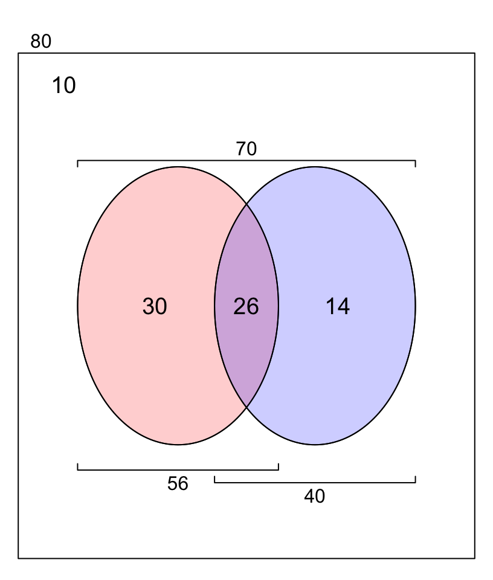

# Meta-information

extype: cloze exclozetype: schoice|schoice|schoice|schoice exsolution: 10000|00001|00010|01000 exname: venn_clubs